El detergente es una sustancia con capacidad peptizante física y química. Esto significa que cuando se diluye con líquido, atraerá y dispersará partículas de suciedad en ropa, platos u otros objetos. Todo esto en general sin causar desgaste ni corrosión, es decir, se utiliza para la limpieza porque tiene propiedades que permiten eliminar la suciedad sin afectar el material [1]. Por ello, podemos hablar de diferentes categorías de detergentes en función de su uso o en distintas presentaciones, como líquido, polvo o pastillas. También se dividen en agentes de limpieza orgánicos y agentes de limpieza químicos. Los limpiadores orgánicos se refieren a limpiadores que no contienen contaminantes y sustancias tóxicas para el medio ambiente y los seres humanos, mientras que los limpiadores químicos están hechos de sustancias sintéticas que han sido probadas en laboratorios y generalmente tienen un rendimiento superior a los limpiadores orgánicos.

En este Diseño de Experimentos se intentará resolver un problema surgido de una situación cotidiana: ir de compras. Cuando compramos detergentes para ropa, nos damos cuenta del cambio en el precio de las diferentes marcas existentes en el mercado, pero ¿este aumento de precio está relacionado con una mayor eficiencia? El diseño presentado incluirá el uso de tres tipos de detergentes para la eliminación de nuestras manchas, presentados más adelante, con el objetivo de incluirlos en la comparativa de su efectividad.

En base a los resultados que podemos obtener, se podrá concluir cómo pueden cambiar nuestros hábitos de consumo para mejorar la economía doméstica, en base a los productos que usamos a diario, como en el caso de los detergentes para ropa. Este informe presenta la realización del proyecto experimental, que consiste principalmente en mediciones de la eficacia de algunas marcas de detergentes líquidos en determinados tipos de tejidos. trata de determinar si el tipo de tela y la marca de detergente son factores importantes que afectan significativamente la variable respuesta (eficiencia de remoción de manchas). Lo que sigue es una descripción general del problema a tratar, así como una explicación de cómo se llevó a cabo el diseño experimental.

Es bien sabido que en cada uno de los hogares se presenta el problema de la remoción de las manchas causadas por diferentes sustancias que caen sobre la ropa, o en cualquier lugar del hogar; esto se presenta en cualquier circunstancia de la vida cotidiana; es por esto que los detergentes más comunes son los que se usan en los hogares, ya sea para la limpieza de la zona de la cocina o para el lavado de la ropa. Este trabajo se enfocará en los detergentes líquidos y su eficiencia a la hora de remover manchas en cuatro diferentes tipos de tela (*scuba*, microfibra, lino y poliéster). Por lo tanto, se desea conocer qué tipo de marca de detergente líquido resulta ser más eficiente al momento de eliminar un tipo de mancha en específico, sobre determinados tipos de tela. Entonces, de ahí parte el interés en encontrar evidencia suficiente que permita recomendar alguna marca en específico, en su eficacia en la eliminación de manchas por sobre las demás que son puestas a prueba.

Observar y determinar que tipo de detergente es el más efectivo para la remoción de un tipo de mancha en específico, sobre determinados tipos de tela, con el fin de encontrar diferencias significativas entre las marcas de detergentes y su eficiencia; así mismo, conocer como reaccionan las diferentes marcas de detergente frente a los tipos de tela. También, reconocer si esta influye en la remoción de la mancha. Además, Observar si el detergente más económico es aquel que presenta la menor eficacia a la hora de eliminar manchas.

### Tipo de diseño experimental

A fin de estudiar el efecto de los tres tipos de detergentes sobre los cuatro distintos tipos de tela a la hora de mitigar la mancha causada por vino, se propone un diseño factorial de dos factores con efectos fijos.

- **Unidad experimental:** Cada uno de los retazos de tela.
- **Factores:** Tipo de tela y las distintas marcas de detergente líquido.
- **Niveles del factor:** Las combinaciones resultantes de combinar los niveles del factor **tela**: *Scuba*, Lino, Microfibra y Poliéster; y los niveles del factor **detergente** desde el más económico, hasta el más costoso: *Bonaropa*, *Límpido* y *Vanish*.
- **Variable respuesta:** Calificación promedio de la eficiencia de los detergentes obtenida gracias a las observaciones de los cuatro integrantes del equipo, siendo 5 la calificación más alta y 1 la más baja.
1. Tipo de tela
   - **Scuba:** Grueso tejido de punto con trama en Licra e hilado de fibra torzal, con un gramaje de 275gsm. Scuba es una tela sólida realizada a través de la combinación de fibras de poliéster, entre las que se incluye el Policloropeno. Con una estructura con elasticidad en los 4 sentidos, especialmente en la trama. [2]
   - **Poliéster:** El Poliéster es una fibra sintética que ofrece un abanico muy amplio de posibilidades: La intensidad del color de la estampación es mayor. Mayor resistencia a humedades, abrasiones y condiciones climáticas extremas. Fácil lavado. [3]
   - **Microfribra:** La Microfibra es una fibra sintética y es altamente empleada en el mundo textil tanto para la elaboración de Toallas Deportivas y de Playa como material de limpieza. Se caracterizan por los hilos empleados en su fabricación, siendo cien veces más finos que el cabello humano. [4]
   - **Lino:** La tela de lino es una fibra vegetal que se compone principalmente de celulosa. Procede del tallo de la planta de lino, cuya semilla, comestible, se llama linaza. [5]

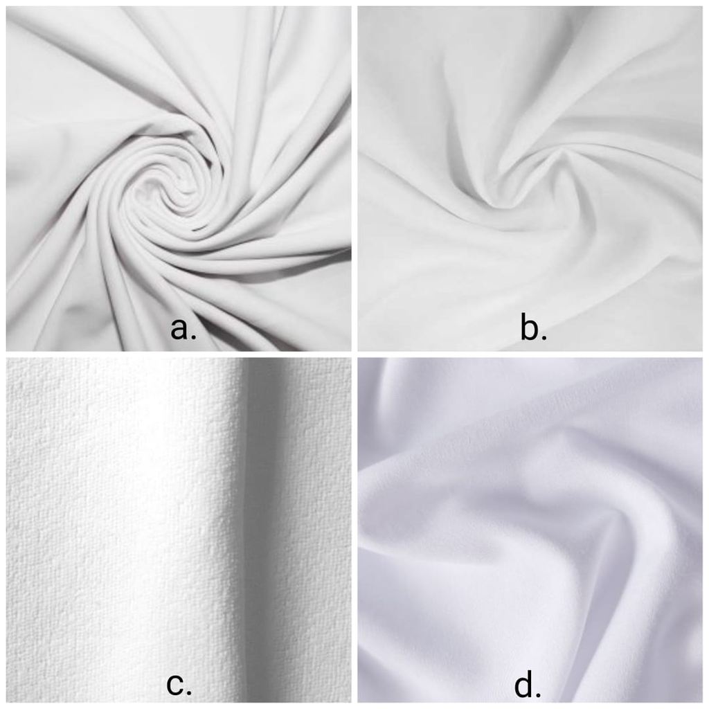

Tipos de tela: a) Scuba, b) Poliéster, c) Microfibra y d) Lino

2. Tipo de detergente, ordenados del más económico al más costoso, con la descripción que traen en sus etiquetas:
   - **Bonaropa:** quitamanchas para ropa blanca. 1000 ml precio: $3.890 pesos.
   - **Límpido:** ofrece un gran poder de desinfección necesario para la limpieza del hogar. Su alto nivel de concentración elimina hasta el 99,9% de gérmenes y bacterias. También es un excelente producto para remover las manchas difíciles. 1000 ml precio: $4.328 pesos.
   - **Vanish:** es un quitamanchas sin cloro que elimina las manchas más dificiles de tus prendas a la vez que hace tus blancos más blancos. Ahora con su fórmula mejorada tambien elimina hasta el 99.9% de bacterias.. 1000 ml precio $10.278 pesos.

[figure not shown]

Tipos de detergente líquido: a) Bonaropa, b) Límpido y c) Vanish ropa blanca

Para llevar a cabo este diseño experimental, primero se compró medio metro de tela de cada uno de los tipos de tela (*scuba*, poliéster, microfibra y lino). Dado que se buscaba tener cierto nivel de variabilidad en cuanto los tipos de tela, la *scuba* resulta ser muy fina y delgada, mientras que la tela en lino resulta ser un poco más gruesa y lisa. Por otro lado, la tela en microfibra resulta ser la más lanuda y gruesa a diferencia de la tela poliéster que presenta ser la más delgada y “fragil” de todas. Con la compra de estas cuatro telas, cuyos precios por medio metro fueron de 9.000 pesos colombianos para la tela en microfibra, 9.500 pesos para la tela en poliéster, 8.000 para la tela en lino y 8.500 para la tela en *Scuba*. Se espera tener una variedad suficiente de telas que permita dar a conocer el efecto del detergente líquido a la hora de remover manchas, en este caso en particular una mancha de vino.

Posteriormente, se compró en un almacén del *D1* la sustancia a ser echada en la tela, en este caso se optó por el vino, puesto que se concluyó que con estos cuatro tipos de tela blanca la mancha sería muy visible, en consecuencia esto permite que a la hora de realizar la calificación por cada uno de los integrantes la mancha sea lo que más resalte de la tela, ya sea por su ausencia o presencia de la misma después de aplicar el tratamiento (detergente líquido). Después se compraron las tres distintas marcas de detergente líquido también en un establecimiento *D1* los cuales fueron *Bonaropa* de 1000 ml costo 3.890 pesos, *Limpido* de 1000 ml costo 4.328 pesos y *Vanish* de 1000 ml costo 10.278 pesos.

Adicionalmente, se utilizaron materiales secundarios para la realización de dicho experimento, materiales tales como: 2 tarros para muestras de orina, tijeras, marcadores, lápiz, cinta de enmascarar,, vasos transparentes desechables y un gotero. Ya después de haber conseguido estos materiales se procedió a realizar la muestra piloto, dicho procedimiento se detalla seguidamente.

Se realizó una prueba piloto con el fin de identificar qué inconvenientes se pueden llegar a presentar al momento de realizar el experimento final. El diseño piloto se llevó a cabo de la siguiente manera: de las 20 divisiones de cada tipo de tela se escogió de manera aleatoria 3 retazos de tela para cada uno de los 3 diferentes tipos de detergentes, estos retazos fueron cortados y luego manchados cada uno con 3 gotas de vino y se esperó un lapso de 1 minuto para que la mancha se acentuará sobre la tela y luego se procedió a dejar el retazo de tela remojando en la solución de agua con cada uno de los detergentes durante dos minutos.

Se contempló además de vino, usar chocolate para manchar los retazos de tela, pero debido al espesor del chocolate, las gotas de chocolate que se aplicaban no se adherían a los retazos de tela.

De los resultados obtenidos de la realizacion de la prueba piloto, se llego a las siguientes observaciones:

- A la tela *scuba* le tomaba más tiempo absorber las gotas de vino en comparación a los otros 3 tipos de tela.
- Las 20 divisiones de 10x10cm, fueron escogidas de manera que se optimizará la limitada cantidad de tela que se tenía a disposición.
- Para medir la eficacia del detergente al eliminar la mancha de vino, cada uno de los experimentadores le dió una calificación de 1 a 5, siendo 1 que no quitó nada la mancha y 5 quitó completamente la mancha.
- Para evitar sesgos a la hora de dar la calificación a cada detergente, cada uno de los experimentadores dio una nota sin conocer la nota dada por los otros experimentadores.
- El estudio piloto sirvió para determinar cuál era el tiempo adecuado para dejar acentuar la mancha en la tela.
- El estudio piloto sirvió para determinar cuál era el tiempo adecuado para dejar el retazo de tela sumergido en la solución de agua con cada uno de los diferentes tipos de tela.

Para el proceso de aleatorización se llevo a cabo lo siguiente:

**1.** Para cada uno de los tipos de tela se realizó una división de 20 fragmentos de 10x10cm.

**2.** Se le asignó un número a cada una de las 20 divisiones en cada uno de los diferentes tipos de tela.

**3.** Se pusieron en un vaso desechable 20 papelitos con el números del 1 a 20, de esos se escogieron 3 números aleatorios, para seleccionar qué división de la tela fue cortada y manchada con vino, donde el primer número aleatorio corresponde al retazo de tela que fue sumergido en la solución de agua y el detergente *Bonaropa*, el segundo número aleatorio corresponde al retazo de tela que fue sumergido en la solución de agua y el detergente *Límpido*. El tercer número aleatorio corresponde al retazo de tela que fue sumergido en la solución de agua y el detergente *Vanish*.

**4.** Este proceso anterior se repitió con cada una de las diferentes tipos de tela.

Después de haber obtenido las unidades experimentales producto de la aleatorización. Se realizaron 3 réplicas del diseño factorial para investigar el efecto de las telas y de los detergentes en la eficiencia al eliminar una mancha de vino. Esencialmente, se les aplicó a las telas tres gotas de vino, utilizando un gotero y velando porque el perímetro de las manchas para cada tipo de tela fuera el más similar posible. Se esperó un tiempo prudencial de cinco minutos, tiempo en el cual el vino ya se había secado en todas las telas.

Posteriormente, se sumergió las telas en vasos desechables que contenían agua y el detergente en cuestión, específicamente se echaron dos basados de agua por uno de detergente usando como medidor un frasco para muestras de orina de 56.3 mm. Se esperó un tiempo de aproximadamente cinco minutos, entre cada tanda de telas, es decir, las tres corridas de tela distintas por tela y detergente. También, se registraron los órdenes en que fueron tomadas las mediciones.

Finalmente, se extrajeron las telas y se escurrieron, luego se organizaron preservando el orden en el cual se habían aplicado los tratamientos a la tela. Seguidamente, cada integrante del equipo de manera individual observaba cada una de las telas y realizaba la calificación. Así mismo para cada una de las tandas o corridas experimentales realizadas.

```r
#Datos
Detergente <- as.factor(c(rep(c("Bonaropa","Límpido","Vanish"), 12)))
Tela <- as.factor(c(rep("Scuba", 9), rep("Poliéster", 9), rep("Microfibra", 9), rep("Lino", 9)))

Promedio <- c(3.25,4.5,2.5,3.25,4.75,2.5,3.75,5,1.5,
              1.5,5,1.5,1.25,4,1.25,1.5,5,1.5,
              3.25,5,3.5,3.75,5,3.25,4.25,4.5,4,
              3.75,5,4.75,4.5,5,4.5,4.5,5,3.75)
datos <- data.frame(Tela, Detergente, Promedio)

modPromedio <- aov(Promedio~Detergente*Tela)
resumen1 <-summary(modPromedio)
```

```r
mediaDeter <- tapply(Promedio,Detergente, mean)
desvD <- tapply(Promedio, Detergente, sd)

mediaTela <- tapply(Promedio, Tela, mean)
desvS <- tapply(Promedio, Tela, sd)

Interaccion <- tapply(Promedio, list(Detergente, Tela), mean)
InteraccionSd <- tapply(Promedio, list(Detergente, Tela), sd)
```

- En el siguiente gráfico se presentan las medias por cada nivel de los factores y de la interacción entre ellos:
1. Estimación de la media global $\mu$, siendo $N=n\times12=3\times12=36$:

$$\hat{\mu} = \bar{\textbf{Y}}... ~=
\frac{Y_{...}}{\textbf{N}}~=~3.63$$

2. Estimación del efecto *Detergente* $\tau_i, ~ i= 1:Bonaropa, ~ 2:Límpido, ~3: Vanish$

$$\hat{\tau}_i =
\bar{\textbf{Y}}_{i..}-\bar{\textbf{Y}}_{...}, \ \ i=1,2,3$$

- $\hat{\tau_1} = \bar{\textbf{Y}}_{1..}-\bar{\textbf{Y}}_{...}\\$ $\hat{\tau_1} = 3.21 - 3.63=-0.42$
- $\hat{\tau_2} = \bar{\textbf{Y}}_{2..}-\bar{\textbf{Y}}_{...}\\$ $\hat{\tau_2}= 4.81 - 3.63 = 1.18$
- $\hat{\tau_3} = \bar{\textbf{Y}}_{3..}-\bar{\textbf{Y}}_{...}\\$ $\hat{\tau_3} = 2.88 - 3.63 = -0.75$
3. Estimación del efecto *Tela* $\beta_j$

$$\hat{\beta_j} =
\bar{\textbf{Y}}_{.j.}-\bar{\textbf{Y}}_{...}, \
~j~=~1:Lino,~2:Microfibra,~3:Poliéster,~4:Scuba$$

- $\hat{\beta_1} = \bar{\textbf{Y}}_{.1.}-\bar{\textbf{Y}}_{...}$ $\hat{\beta_1} = 4.53-3.63=0.9$
- $\hat{\beta_2} = \bar{\textbf{Y}}_{.2.}-\bar{\textbf{Y}}_{...}$ $\hat{\beta_2}= 4.06-3.63= 0.43$
- $\hat{\beta_3} = \bar{\textbf{Y}}_{.1.}-\bar{\textbf{Y}}_{...}$ $\hat{\beta_3} = 2.50-3.63=-1.13$
- $\hat{\beta_4} = \bar{\textbf{Y}}_{.2.}-\bar{\textbf{Y}}_{...}$ $\hat{\beta_4}= 3.44-3.63= -0.19$
4. Estimación de las *interacciones* $\hat{(\tau \beta)}_{ij}$

$$\hat{(\tau \beta)}_{ij} ~=~
\bar{Y}_{ij.}-\bar{Y}_{i..}-\bar{Y}_{.j.}+\bar{Y}_{...}$$

- $\hat{(\tau \beta)}_{11} ~=~ \bar{Y}_{11.}-\bar{Y}_{1..}-\bar{Y}_{.1.}+\bar{Y}_{...} \\$ $\hat{(\tau \beta)}_{11} ~=~ 4.25-3.21-4.53+3.63 = 0.14$
- $\hat{(\tau \beta)}_{12} ~=~ \bar{Y}_{12.}-\bar{Y}_{1..}-\bar{Y}_{.2.}+\bar{Y}_{...} \\$ $\hat{(\tau \beta)}_{12} ~=~ 3.75-3.21-4.06+3.63=0.11$
- $\hat{(\tau \beta)}_{13} ~=~ \bar{Y}_{13.}-\bar{Y}_{1..}-\bar{Y}_{.3.}+\bar{Y}_{...} \\$  
  $\hat{(\tau \beta)}_{13} ~=~ 1.42-3.21-2.50+ 3.63 = -0.66$
- $\hat{(\tau \beta)}_{14} ~=~ \bar{Y}_{14.}-\bar{Y}_{1..}-\bar{Y}_{.4.}+\bar{Y}_{...} \\$ $\hat{(\tau \beta)}_{14} ~=~ 3.42-3.21-3.44+ 3.63=0.4$
- $\hat{(\tau \beta)}_{21} ~=~ \bar{Y}_{21.}-\bar{Y}_{2..}-\bar{Y}_{.1.}+\bar{Y}_{...} \\$ $\hat{(\tau \beta)}_{21} ~=~ 5.00-4.81-4.53+ 3.63 = -0.71$
- $\hat{(\tau \beta)}_{22} ~=~ \bar{Y}_{22.}-\bar{Y}_{2..}-\bar{Y}_{.2.}+\bar{Y}_{...} \\$ $\hat{(\tau \beta)}_{22} ~=~ 4.83-4.81-4.06+ 3.63 = -0.41$
- $\hat{(\tau \beta)}_{23} ~=~ \bar{Y}_{23.}-\bar{Y}_{2..}-\bar{Y}_{.3.}+\bar{Y}_{...} \\$ $\hat{(\tau \beta)}_{23} ~=~ 4.67-4.81-2.50+3.63 = 0.99$
- $\hat{(\tau \beta)}_{24} ~=~ \bar{Y}_{24.}-\bar{Y}_{2..}-\bar{Y}_{.4.}+\bar{Y}_{...} \\$ $\hat{(\tau \beta)}_{24} ~=~ 4.75-4.81-3.44+3.63=0.13$
- $\hat{(\tau \beta)}_{31} ~=~ \bar{Y}_{31.}-\bar{Y}_{3..}-\bar{Y}_{.1.}+\bar{Y}_{...} \\$  
  $\hat{(\tau \beta)}_{31} ~=~ 4.33-2.88-4.53+ 3.63 = 0.55$
- $\hat{(\tau \beta)}_{32} ~=~ \bar{Y}_{32.}-\bar{Y}_{3..}-\bar{Y}_{.2.}+\bar{Y}_{...} \\$ $\hat{(\tau \beta)}_{22} ~=~ 3.58-2.88-4.06+ 3.63=0.27$
- $\hat{(\tau \beta)}_{33} ~=~ \bar{Y}_{33.}-\bar{Y}_{3..}-\bar{Y}_{.3.}+\bar{Y}_{...} \\$ $\hat{(\tau \beta)}_{33} ~=~ 1.42-2.88-2.50+ 3.63 = -0.33$
- $\hat{(\tau \beta)}_{34} ~=~ \bar{Y}_{34.}-\bar{Y}_{3..}-\bar{Y}_{.4.}+\bar{Y}_{...} \\$ $\hat{(\tau \beta)}_{34} ~=~ 2.17-2.88-3.44+ 3.63 = -0.52$

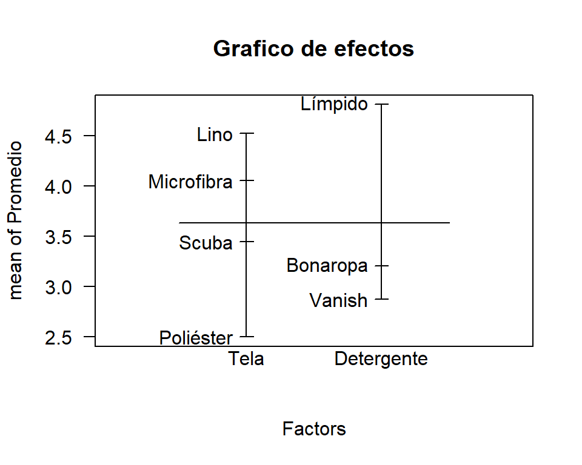

Gráfico de efectos

```r
plot.design(Promedio~Tela*Detergente, main = "Grafico de efectos", las = 1)
```

- Del gráfico se puede observar que el tipo de **Detergente** Límpido presenta un mayor promedio de calificación de eficiencia en la eliminación de manchas de vino, con respecto a los otros dos detergentes, además, se observa que el efecto es más alto con respecto a los otros.
- Sobre el factor **Tela** se puede observar que los tipos de tela Lino y Microfibra ofrecen en promedio mayor calificación con respecto a la media global, mientras que los tipos de tela Scuba y Poliéster, ofrecen una menor calificación promedio con respecto a la media global.

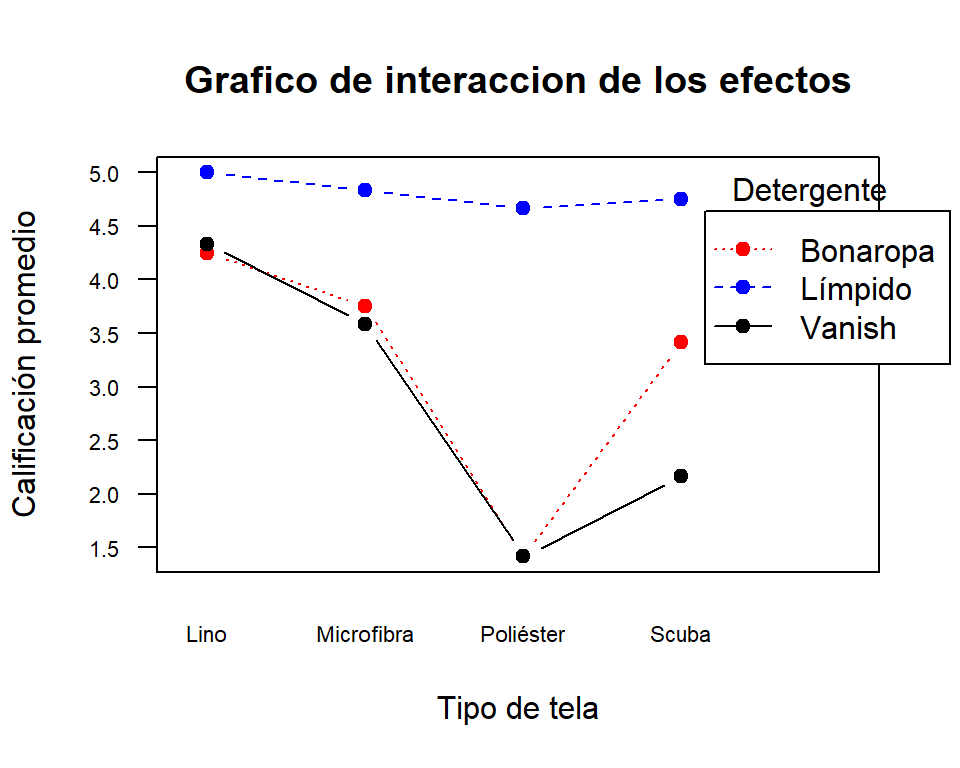

Gráfico de interacción de los efectos - 1

```r
interaction.plot(Tela, Detergente, Promedio, type = "b", pch = 19, fixed = T, xlab = "Tipo de tela", ylab = "Calificación promedio", main = "Grafico de interaccion de los efectos", las = 1, col=c("red", "blue", "black"), cex.axis=.7, leg.bty =0.1)
```

- Se puede observar en el gráfico que, el detergente **Límpido** tiende a obtener una mejor calificación promedio en la eficiencia a la hora de eliminar manchas de vino, con respecto a los demás detergente, para cada uno de los tipos de tela.
- También se puede observar que los Detergentes **Bonaropa** y **Vanish** obtienen calificaciones similares en cuanto a la eficiencia al momento de eliminar manchas de vino en cada una de las telas, a exepción del tipo de tela **scuba**, que tiene menores calificacione con respecto a las demás.

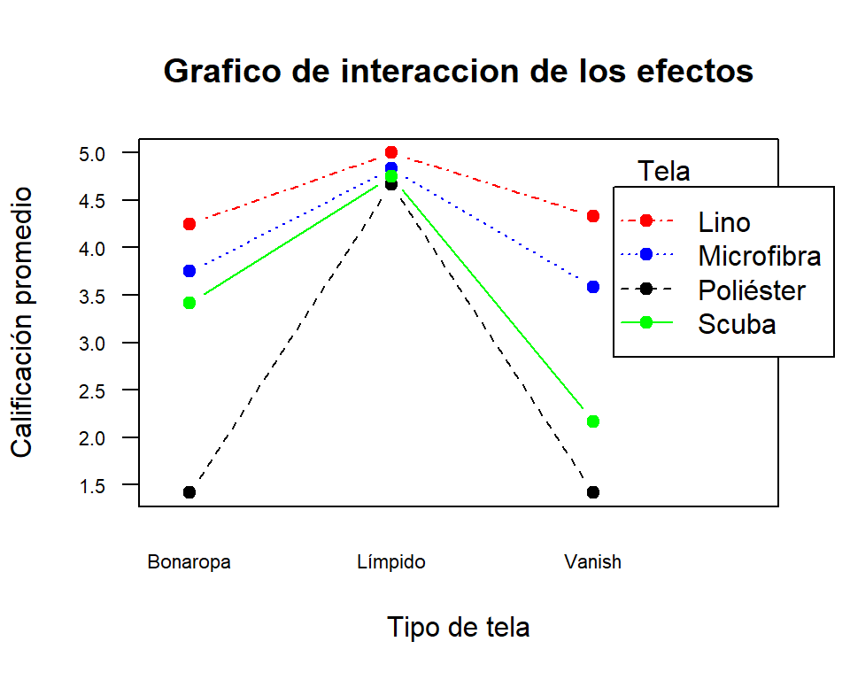

Gráfico de interacción de los efectos - 2

```r
interaction.plot(Detergente, Tela, Promedio, type = "b", pch = 19, fixed = T, xlab = "Tipo de tela", ylab = "Calificación promedio", main = "Grafico de interaccion de los efectos", las = 1, col=c("red", "blue", "black", "green"), cex.axis=.7, leg.bty =0.1)
```

- Se observa que para cada una de las telas, al usar detergente **Límpido** obtuvieron mejores calificaciones promedio de eficiencia al momento de eliminar una mancha de vino.
- Tambien se observa la gran diferencia que hay en el promedio de eficiencia al momento de eliminar una mancha cuando se trata de un tipo de tela **Poliéster**, ya que en el detergente más económico y en el más costoso, sus calificaciones fueron muy por debajo a lo referente al tipo de detergente que se encuentra en la mitad de los rangos de precios de los demás.
- En general, se observa que hay una notable diferencia entre todos los tipos de tela con el detergente límpido, con respecto a las demás interacciones.

**Modelo estadístico:**

$$Y_{ijk} = \mu + \tau_i + \beta_j +
(\tau\beta)_{ij} + \varepsilon_{ijk}$$

- $\mu:$ Media global.
- $\tau_i:$ Efecto del i-esimo nivel del factor A (marcas de detergente liquido), con $i=1,2,3$.
- $\beta_j:$ Efecto del j-esimo nivel del factor B (Tipos de tela), con $i=1,2,3,4$.
- $(\tau\beta)_{ij}:$ Efecto de la interacción entre A y B, con $i=1,2,3$ y $j=1,2,3,4$.
- $\varepsilon_{ijk}:$ Término de error.

**Supuestos**

$$\varepsilon_{ijk} \sim NID(0, \sigma
^2)$$

**Restricción**

$$\sum \tau_i = \sum \beta_j = \sum_i
(\tau\beta)_{ij} = \sum_j (\tau\beta)_{ij} = 0$$

**Nota:** Dado que los detergentes y los tipos de telas fueron seleccionados explicitamente por los integrnates del grupo, se considera un diseño de efectos fijos, por lo tanto, se plantean, interpretan y realizan las pruebas de hipotesis que establecen la significancia de la interaccion y de los factores y se analiza el posible encubrimiento de los factores.

Para cada uno de los factores y la interacción entre ellos se realizan las respectivas pruebas de significancia:

1. Significancia de la *interacción* de los factores del diseño:

Se plantea las siguiente prueba de hipótesis:

$$\begin{cases}
\begin{aligned}
H_0&: (\tau \beta)_{ij}~ = 0, \forall~i=1,2,3, ~j=1,2,3,4 \\
H_a&: (\tau \beta)_{ij}~\neq0,~p.a~~i=1,2,3, ~j=1,2,3,4\
\end{aligned}
\end{cases}$$

```r
modPromedio <- aov(Promedio~Detergente*Tela)
```

El estadístico de prueba para la significancia de la interacción es:

$$F_0=\frac{MSAB}{MSE} =
\frac{1.527}{0.149}= 10.24832$$

Región de rechazo de la prueba bajo $H_0$:

$$F_{cal}>F_{\alpha,(a-1)(b-1),ab(n-1)}$$
$$F_{cal}>F_{0.05,(3-1)(4-1),3\times4(3-1)}$$

Como el valor de $F_{cal}> 2.508189$, se rechaza la hipótesis nula.

**Conclusión**: Dado que el valor P de la prueba es $1.22e^{-05} < \alpha=0.05$ se rechaza la hipótesis nula, es decir, la *interacción* entre los factores, Tela y Detergente es significativo a un nivel de confianza del 5%.

2. Significancia del factor *Detergente*

Se plantea la siguiente prueba de hipótesis para verificar la significancia del factor Detergente:

$$\begin{cases}
\begin{aligned}
H_0&: \tau_{1}=\tau_{2}=\tau_{3}~ = 0 \\
H_a&: \tau_{i}~\neq0,~~p.a~~i=1,2,3\
\end{aligned}
\end{cases}$$

El estadístico de prueba para la significancia del factor Detergente es:

$$F_0=\frac{MSA}{MSE} =
\frac{12.877}{0.149}= 86.42282$$

La región de rechazo bajo $H_0$ es:

$$F_{cal}>F_{\alpha,(a-1),ab(n-1)}
~~~~~| ~~~~~a=3,b=4,n=3$$

**Conclusión:** Se rechaza la hipótesis nula, es decir, el factor *Detergente* es significativo a un nivel de confianza del 5%.

3. Significancia del factor *Tela*

Se plantea la siguiente prueba de hipótesis para verificar la significancia del factor Tela:

$$\begin{cases}
\begin{aligned}
H_0&: \beta_{1}=...=\beta_{4} = 0 \\
H_a&: \beta_{j}~\neq0,~~p.a~~j=1,2,3,4\
\end{aligned}
\end{cases}$$

El estadístico de prueba para la significancia del factor Tela es:

$$F_0=\frac{MSB}{MSE} =
\frac{6.895}{0.149}= 46.27517$$

La región de rechazo bajo $H_0$ es:

**Conclusión:** Se rechaza la hipótesis nula, es decir, el factor *Tela* es significativo a un nivel de confianza del 5%.

**Conclusiones generales sobre significancia de los factores:**

- No se presenta *Encubrimiento* de la significancia de ninguno de los factores del diseño experimental, dado que tanto la interacción como cada uno de los factores son significativos a un nivel de confianza del 5%.

Para verificar la normalidad de los errores del modelo, se plantea la siguiente prueba de hipótesis:

$$\begin{cases}
\begin{aligned}
H_0&: \varepsilon_{ijk} \sim Normales \\
H_a&: \varepsilon_{ijk} \nsim Normales\
\end{aligned}
\end{cases}$$

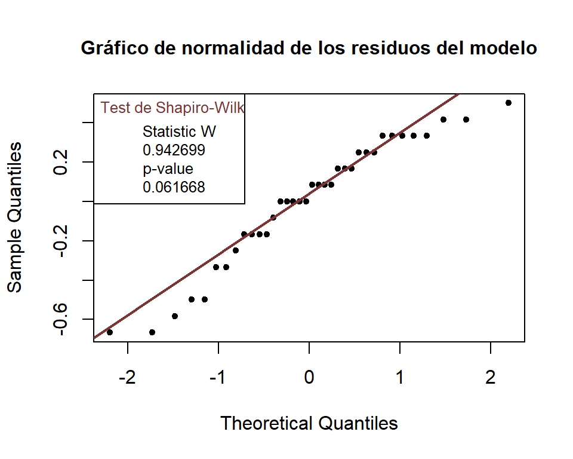

Gráfico Qqplot

```r
residuales <- residuals(modPromedio)
test <- shapiro.test(residuales)
qqnorm(residuales,main="Gráfico de normalidad de los residuos del modelo", cex.main = 1, cex = 1, pch = 20)
qqline(residuales,col="#7d3434", lwd=2)
legend("topleft",title = "Test de Shapiro-Wilk",title.col="#7d3434",title.adj= 1, legend=rbind(c("Statistic W","p-value"), round(c(test$statistic,test$p.value),digits=6)), cex=.8)
```

```r
dwtest <- durbinWatsonTest(modPromedio)
```

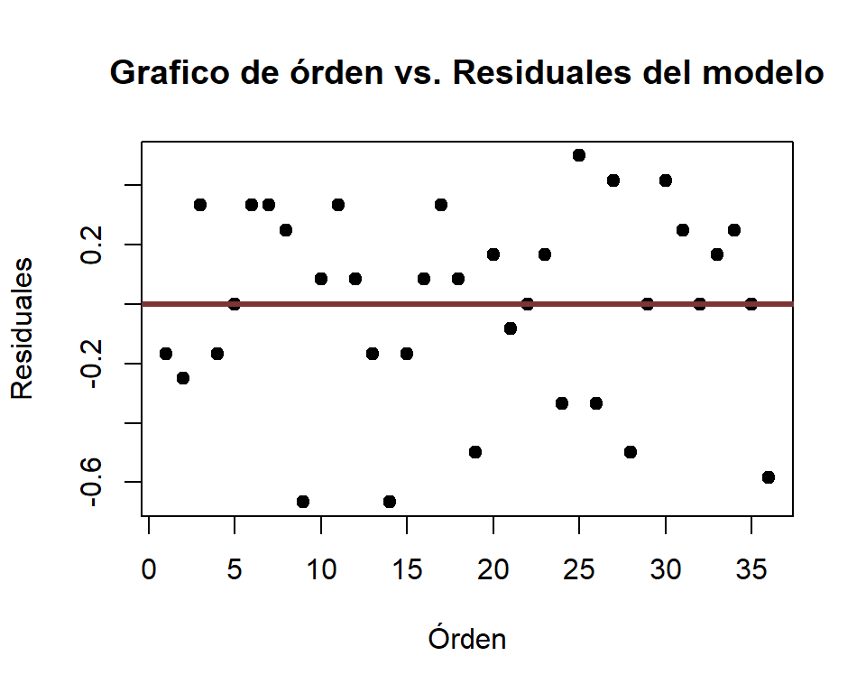

Órden vs. Residuales

```r
plot(residuals(modPromedio), pch=19, col=1,
     main = "Grafico de órden vs. Residuales del modelo",
     xlab = "Órden", ylab = "Residuales")
abline(h=0, col="#7d3434", lwd = 3)
```

Para verificar el supuesto de homogeniedad de varianza se plantea la siguiente prueba de hipótesis:

$$\begin{cases}
\begin{aligned}
H_0&: Var(\varepsilon_{ij})=\sigma^2 \\
H_a&: Var(\varepsilon_{ij})\neq\sigma^2\
\end{aligned}
\end{cases}$$

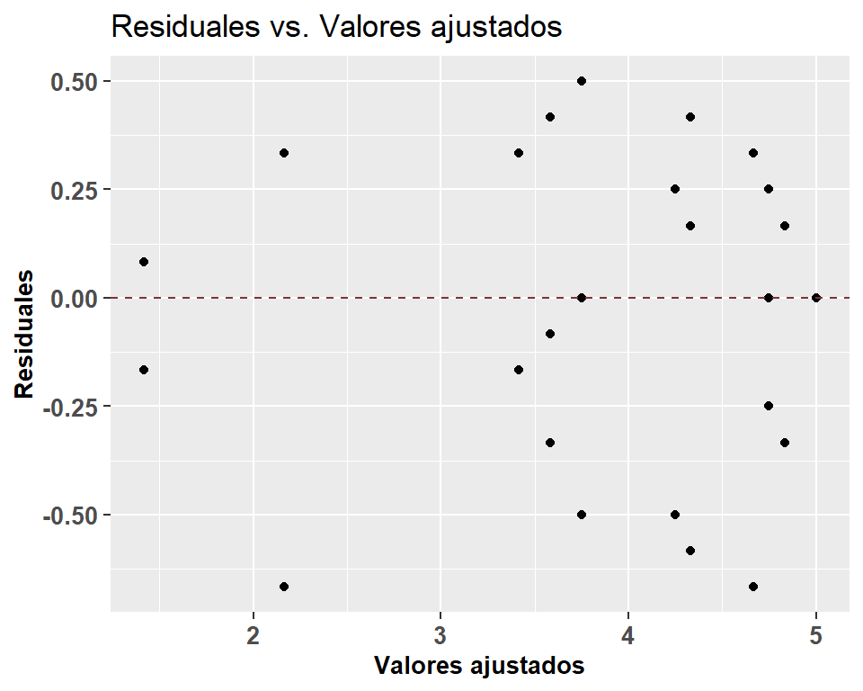

Residuales vs. Valores ajustados

```r
  res<-ggplot(modPromedio, aes(x=modPromedio$fitted.values, y=modPromedio$residuals))+
  geom_point()+
  geom_hline(yintercept=0,
           col="#7d3434", linetype="dashed")+
  theme(axis.title=element_text(size=10,face="bold"),
        axis.text=element_text(size=10, face="bold"))+
  xlab("Valores ajustados")+
           ylab("Residuales")+
  ggtitle("Residuales vs. Valores ajustados")
res
```

```r
b1 <- bartlett.test(residuales, Detergente)
b2 <- bartlett.test(residuales, Tela)
```

Según los resultados anteriores, se quiere responder a la pregunta de cúal de los detergente o tipos de tela tiene una mejor calificación al momento de eliminar una mancha de vino, y como se puedo ver el los gráficos de los efectos, se puede observar que el tipo de detergente Límpido presentaba un puntaje de calificación más alto con respecto a los demás detergentes; y con respecto a las telas, se observaba que el tipo de tela poliéster presenta menores puntajes de eficiencia. Para corroborar lo anterior se plantean diversas pruebas de contrastes, pero antes de esto, se presentan algunos gráficos que permiten corroborar los resultados

1. Boxplot para el factor A: Detergente

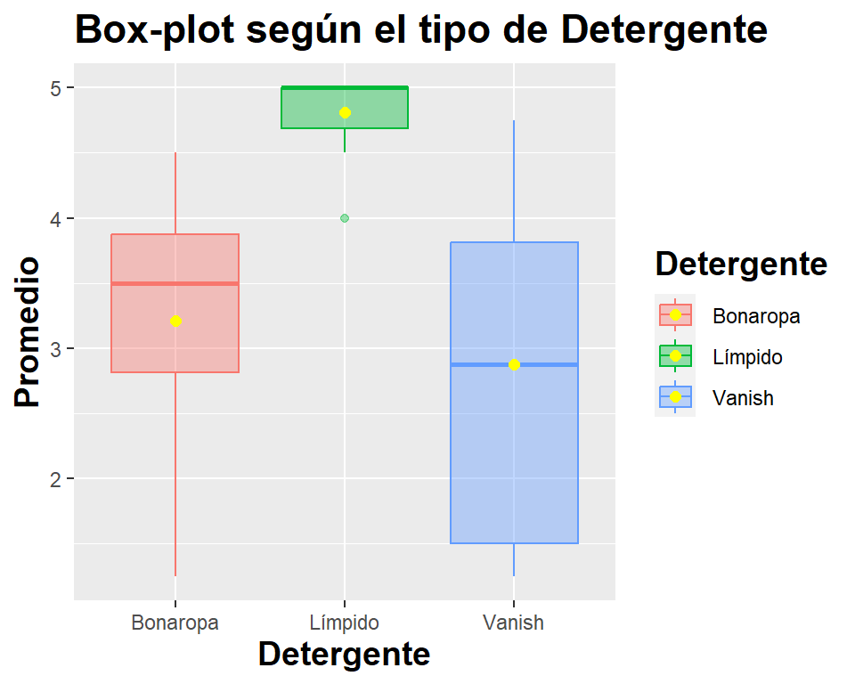

Box-plot para tipo de Detergente

```r
ggplot(datos,aes(y=Promedio, x=Detergente, col=Detergente, fill=Detergente))+labs(title='Box-plot según el tipo de Detergente')+
  geom_boxplot(alpha=0.4)+
  stat_summary(aes(y=Promedio,x=Detergente, group=Detergente),
               fun=mean, geom="point", shape=20,
               size=3, color="yellow")+theme(legend.title=element_text( face='bold', size=14, color='black', hjust=0.5), title=element_text( face='bold', size=14, color='black', hjust=0.5))
```

- Del gráfico se puede observar que el tipo de detergente Límpido es el que presenta menor variabilidad, y el tipo de detergente Vanish es el que presenta una variabilidad mucho mayor con respecto a los otros dos tipos de detergentes.
- Del Box-Plot se podría inferir que existe diferencia significativa entre las medias de los promedios de la eliminación de una mancha de vino según el tipo de detergente, ya que para cada una de las 3 cajas del gráfico, se observan comportamientos diferentes.
2. Boxplot para el factor B: Tipo de tela

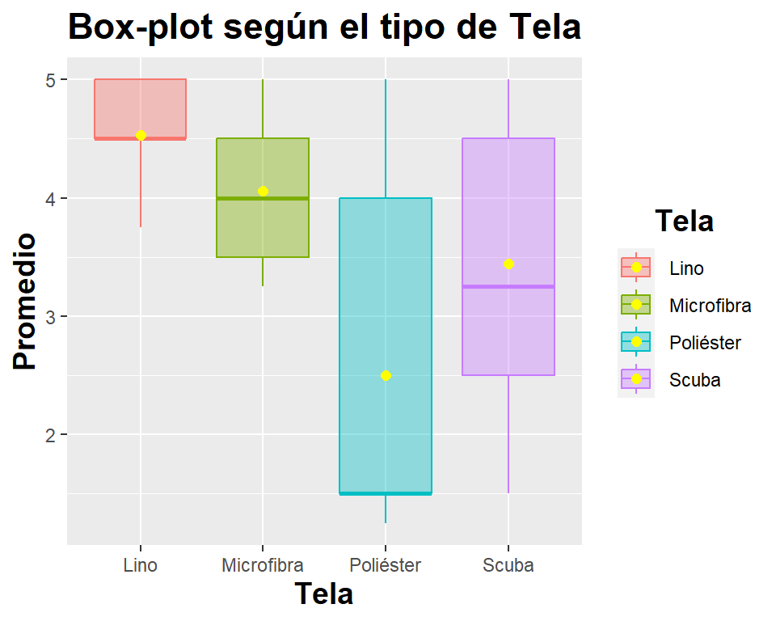

Box-plot para tipo de Tela

```r
ggplot(datos,aes(y=Promedio, x=Tela, col=Tela, fill=Tela))+labs(title='Box-plot según el tipo de Tela')+
  geom_boxplot(alpha=0.4)+
  stat_summary(aes(y=Promedio,x=Tela, group=Tela),
               fun=mean, geom="point", shape=20,
               size=3, color="yellow")+theme(legend.title=element_text( face='bold', size=14, color='black', hjust=0.5), title=element_text( face='bold', size=14, color='black', hjust=0.5))
```

- Del gráfico se puede observar que el tipo de tela Poliéster es la que presenta mayor variabilidad, y el tipo de tela Lino y Microfibra presentan menor variabilidad respecto a los otros dos tipos de telas.
- Del Box-Plot se podría inferir que existe diferencia significativa entre las medias de los promedios de eficiencia de la eliminación de una mancha de vino según el tipo de tela, ya que para cada una de las 4 cajas del gráfico, se observan comportamientos diferentes.

Para determinar si existe diferencia significativa entre las medias según el tipo de Detergente, se platea la siguiente prueba de hipótesis:

$$\begin{cases}
\begin{aligned}
H_0&: \mu_{1..}=\mu_{2..}=\mu_{3..} \\
H_a&: \mu_{i..} \neq\mu_{j..} ~p.a~i\neq j, ~i,j=1,2,3\
\end{aligned}
\end{cases}$$

Para determinar si existe diferencia significativa entre las medias según el tipo de Tela, se platea la siguiente prueba de hipótesis:

$$\begin{cases}
\begin{aligned}
H_0&: \mu_{.1.}=\mu_{.2.}=\mu_{.3.}=\mu_{.4.} \\
H_a&: \mu_{.i.} \neq\mu_{.j.} ~p.a~i\neq j, ~i,j=1,2,3,4\
\end{aligned}
\end{cases}$$

Además de las comparaciones dobles entre los niveles de los factores, también se proponen comparaciones múltiples mediante contrastes con el objetivo de determinar que combinaciones de tratamientos, es decir, que marca de detergente con qué tipo de tela en conjunto, hacen que la eficiencia a la hora de quitar la mancha de vino sea la máxima posible.

Por ello se proponen los siguientes contrastes:

*1.* Se observa que el detergente de la marca *límpido* y el tipo de tela *lino* maximizan la eficiencia en la remoción de la mancha de vino. En contraste con las demas telas poliéster y scuba y el *Límpido*.

El diseño experimental presentado tuvo el fin de dar a conocer la eficiencia de tres marcas de detergentes (*Limpido*, *Bonaropa* y *vanish*) a la hora de eliminar o hasta cierto punto mitigar una mancha causada por el vino en cuatro distintos tipos de tela (lino, *scuba*, poliester y microfibra). A continuación, se presentan conclusiones, observaciones, comentarios y recomendaciones; dadas por los investigadores y que son fruto del desarrollo de este experimento, así como los resultados e impresiones generadas durante la realización del mismo.

Del diseño experimental es menester destacar lo siguiente: